# ggplot2 Elegant Graphics for Data Analysis

## 2.3 Legend Elements

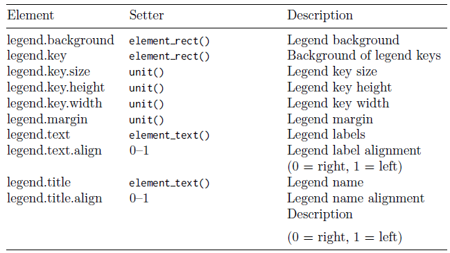

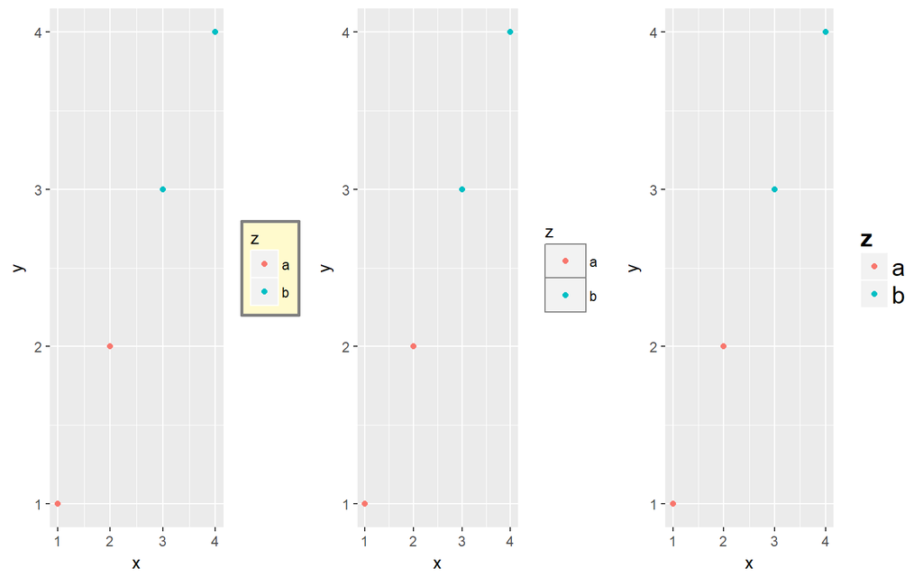

```r
df <- data.frame(x = 1:4, y = 1:4, z = rep(c("a", "b"), each = 2))
base <- ggplot(df, aes(x, y, colour = z)) + geom_point()
grid.arrange(
base + theme(
  legend.background = element_rect(
    fill = "lemonchiffon",
    colour = "grey50",
    size = 1
  )
),
base + theme(
  legend.key = element_rect(color = "grey50"),
  legend.key.width = unit(0.9, "cm"),
  legend.key.height = unit(0.75, "cm")
),
base + theme(
  legend.text = element_text(size = 15),
  legend.title = element_text(size = 15, face = "bold")
), ncol = 3)
```

이 밖에도 legned.position, legend.direction, legend.justification, legend.box가 있다.

## 2.4 Panel Elements

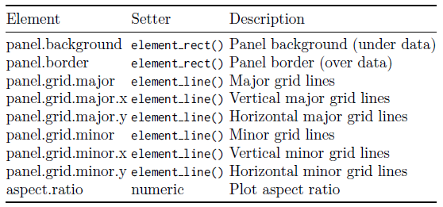

panel.background 와 panel.border의 차이는 background는 데이터 아래에 그려지고 border은 데이터 위에 그려진다는 것이다. panel.border를 오버라이딩 할 때는 fill = NA할당이 필요하다.

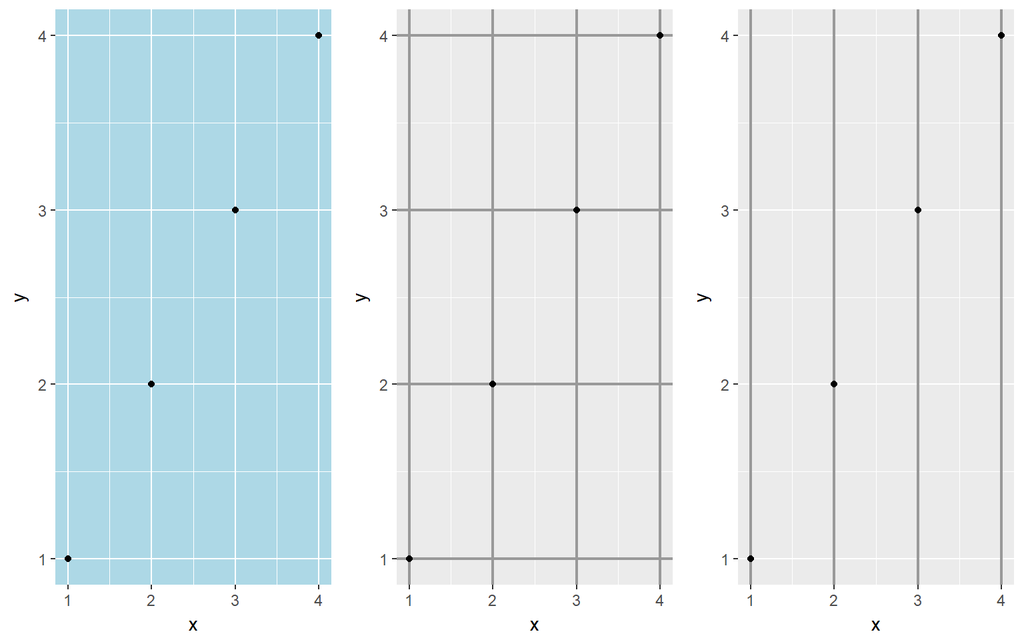

```r
base <- ggplot(df, aes(x, y)) + geom_point()
grid.arrange(
# Modify background
base + theme(panel.background = element_rect(fill = "lightblue")),
# Tweak major grid lines
base + theme(
  panel.grid.major = element_line(color = "gray60", size = 0.8)
),
# Just in one direction
base + theme(
  panel.grid.major.x = element_line(color = "gray60", size = 0.8)
), ncol = 3)
```

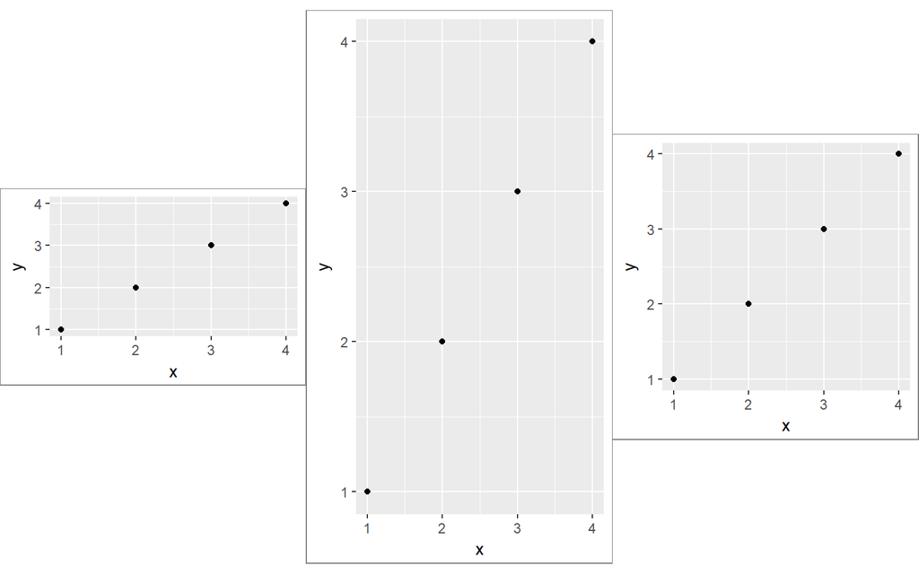

```r
base2 <- base + theme(plot.background = element_rect(colour = "grey50"))
grid.arrange(
# Wide screen
base2 + theme(aspect.ratio = 9/16), #aspect ratio : 가로세로 비율
# Long and skiny
base2 + theme(aspect.ratio = 2/1),
# Square
base2 + theme(aspect.ratio = 1), ncol = 3)
```

## 2.5 Facetting Elements

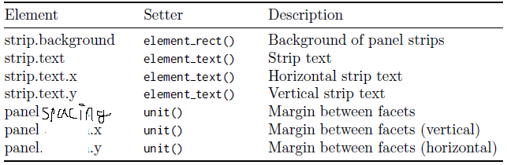

`panel.margin`은 `panel.spacing`으로 변경되었다.

strip.text.x는 facet_wrat()이나 facet_grid()에게 둘다 영향을 주지만 strip.text.y는 오직 facet_grid()에게만 영향을 준다.

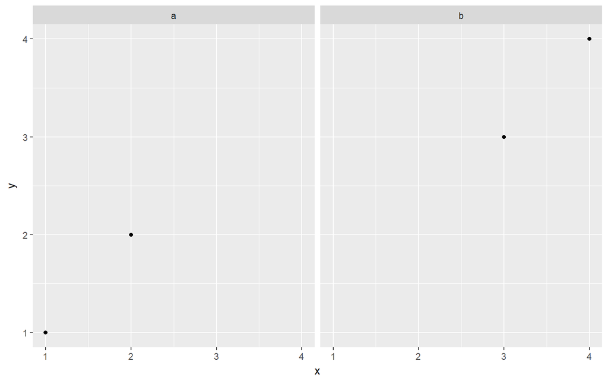

```r
df <- data.frame(x = 1:4, y = 1:4, z = c("a", "a", "b", "b"))
base_f <- ggplot(df, aes(x, y)) + geom_point() + facet_wrap(~z)
base_f
```

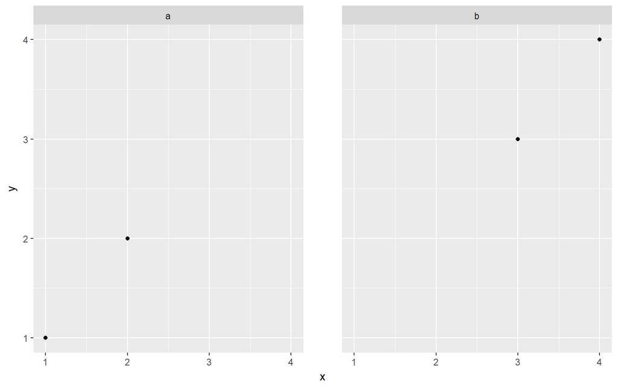

```r
base_f + theme(panel.spacing = unit(0.5, "in"))
```

```r
base_f + theme(
  strip.background = element_rect(fill = "grey20", color = "grey80", size = 1),
  strip.text = element_text(colour = "white")
)
```

[figure not shown]

## 2.6 Exercises

1. theme dark() makes the inside of the plot dark, but not the outside. Change the plot background to black, and then update the text settings so you can still read the labels.

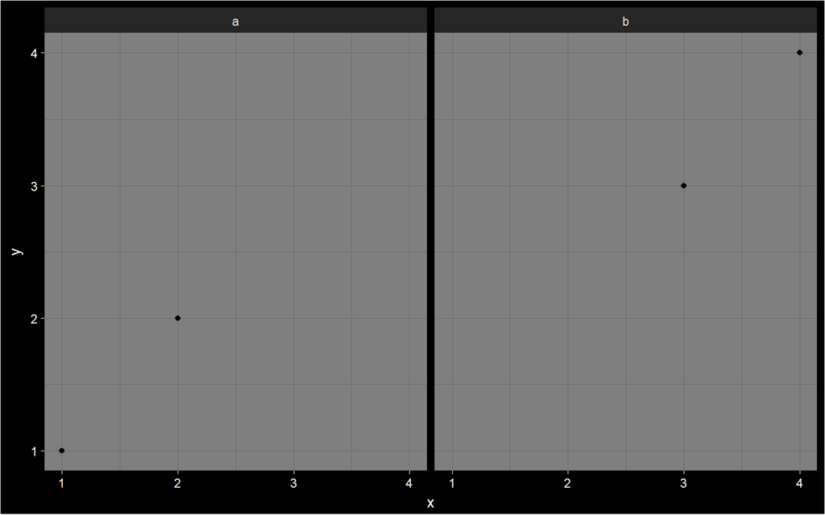

```r
base_f + theme_dark() +
  theme(
  plot.background = element_rect(fill = "black"),
  axis.text = element_text(colour = "white"),
  axis.title = element_text(colour = "white"),
  axis.ticks = element_line(colour = "white")
                              )
```

2. Make an elegant theme that uses “linen” as the background colour and a serif font for the text.

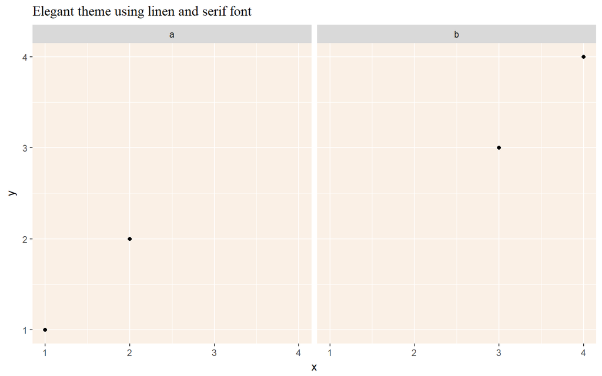

```r
base_f +
  ggtitle("Elegant theme using linen and serif font") +
  theme(panel.background = element_rect(fill = "linen"),
        plot.title = element_text(family = "serif"))
```

3. Systematically explore the effects of hjust when you have a multiline title. Why doesn’t vjust do anything?

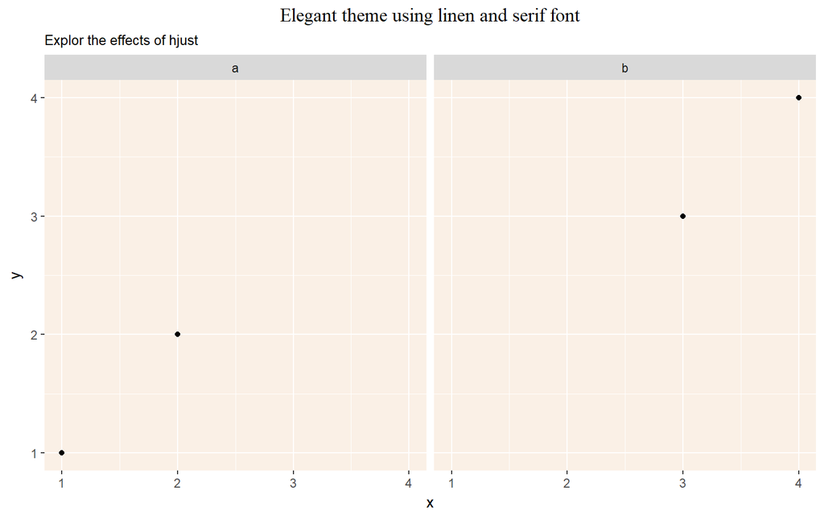

```r
base_f +
  ggtitle("Elegant theme using linen and serif font", subtitle = "Explor the effects of hjust") +
  theme(panel.background = element_rect(fill = "linen"),
        plot.title = element_text(hjust = 0.5, family = "serif"))
```

# 3 Saving Your Output

다른 프로그램에 플랏을 저장할 때 raster와 vector의 두가지 선택권이 있다.

- Vector그래픽 : 선을 (x1, y1)에서 (x2, y2)로 그리고, (x3, x4)에서 반지름 r로 원을 그린다. 세부사항의 손실이 없다. 가장 유용한 벡터 그래픽 포멧은 pdf와 svg이다.
- Raster그래픽 : 픽셀의 배열로 저장되어지고 최적의 사이즈를 가진다. 가장 유욕한 레스터 그래픽은 png이다

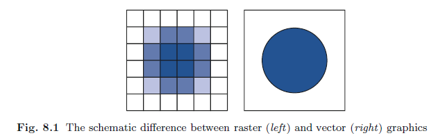

특별한 이유가 없다면 벡터 그래픽을 사용하라. 더 보기 좋다. 레스터 그래픽을 사용하는 두 가지 주된 이유

- 플랏에 그래픽 객체가 굉장히 많다. 벡터버전은 크고 랜더링이 느리다.
- MS Office에 끼워 넣을때. MS는 벡터 그래픽에 대한 지원이 좋지 않다.

표준 R 접근법은 그래픽 디바이스를 열어서 플랏을 생성하여 디바이스를 닫는방법이다.

```r
pdf("output.pdf", width = 6, height = 6)
ggplot(mpg, aes(displ, cty)) + geom_point()
dev.off()
```

이 방법은 장황하므로 `ggsave()`사용

```r
ggplot(mpg, aes(displ, cty)) + geom_point()
ggsave("output.pdf")
```

ggsave()는 상호적인 사용에 최적화되어있다.

- 첫번째 인자, path, 이미지가 저장되어야 할 path를 명시한다. ggsave()는 .eps, .pdf, .svg, .wmf, .png, .jpg, .bmp, .tiff를 생성할 수 있다.
- width그리고 height는 출력 크기를 통제한다.
- 레서트 그래픽을 위해(즉, .png, .jpg) dpi 인자가 플랏의 해상도를 통제한다. 디폴트는 300이지만 고출력 해상도(600)나 web에서 사용하도록 96이 필요할 수 있다.